# Human Activity Recognition Project

### Removing unnecessary time variables and user ID

```r
training %<>%
     dplyr::select(-c(1:7),-classe,-user,-user_name)

testing %<>%
     dplyr::select(-c(1:7),-problem_id)
```

9. Pairs plots

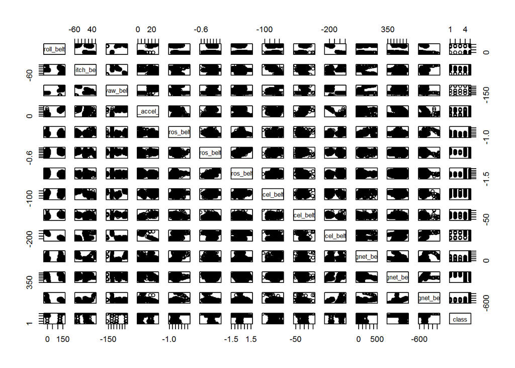

```r
### Belt variables
training %>%
     select(contains("belt"), class) %>%
     pairs(.)
```

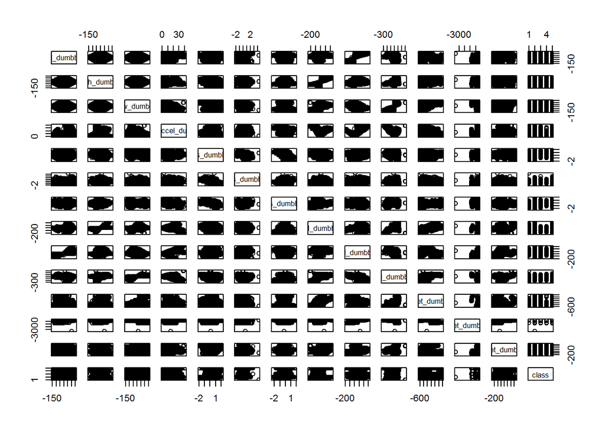

```r
### Arm variables - not shown, fewer apparent potential predictors
# training %>%
#      select(contains("_arm"), class) %>%
#      pairs(.)

### Dumbbell variables
training %>%
     select(contains("dumbbell"), class) %>%
     pairs(.)
```

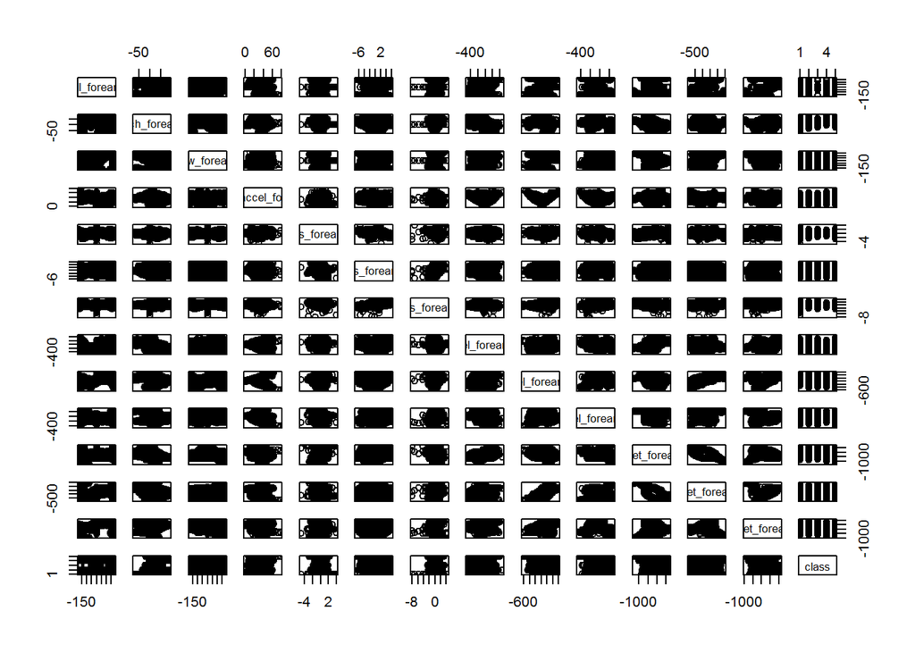

```r
### Forearm variables
training %>%
     select(contains("forearm"), class) %>%
     pairs(.)
```

On gross inspection, `roll_belt`, `yaw_belt`, and the `accel_belt` components appear to be potentially useful predictors.

### Looking for correlation among predictors and trimming predictors

```r
M <- training %>%
     dplyr::select(-class) %>%
     cor(.) %>%
     abs(.)

diag(M) <- 0

which(M > 0.9,arr.ind=T)
```

```
##                  row col
## total_accel_belt   4   1
## accel_belt_y       9   1
## accel_belt_z      10   1
## accel_belt_x       8   2
## roll_belt          1   4
## accel_belt_y       9   4
## accel_belt_z      10   4
## pitch_belt         2   8
## roll_belt          1   9
## total_accel_belt   4   9
## accel_belt_z      10   9
## roll_belt          1  10
## total_accel_belt   4  10
## accel_belt_y       9  10
## gyros_arm_y       19  18
## gyros_arm_x       18  19
## gyros_dumbbell_z  33  31
## gyros_forearm_z   46  31
## gyros_dumbbell_x  31  33
## gyros_forearm_z   46  33
## gyros_dumbbell_x  31  46
## gyros_dumbbell_z  33  46
```

```r
training %<>%
     dplyr::select(-accel_belt_y, -accel_belt_z, -gyros_arm_y, -gyros_forearm_z)

testing %<>%
     dplyr::select(-accel_belt_y, -accel_belt_z, -gyros_arm_y, -gyros_forearm_z)
```

### Fitting a LDA model

```r
ldafit <- train(class ~ ., data = training, preProcess = "scale", method="lda")
```

### LDA model accuracy

```r
ldafit   ### 70% accuracy
```

[output not shown]

The LDA model fits quickly, but unfortunately does not predict well in-sample.

### Testing a tree model

```r
treefit <- train(class ~ ., data = training, preProcess = "scale", method="rpart")
```

### Tree model accuracy

```r
treefit   ### 51% accuracy
```

[output not shown]

A basic classification tree is even worse.

### Pre-processing for RF model

```r
preProcValues <- preProcess(training, method = "scale")
trainproc <- predict(preProcValues, training)
testproc <- predict(preProcValues, testing)
```

### Testing a RF model

```r
control <- trainControl(method = "cv", number = 10)

noy <- trainproc[,-49]

outcome <- training$class

rffit <- train(x = noy,
               y = outcome,
               method="rf",
               trControl = control)
```

After pre-processing by scaling all of the continuous variables, I fit a random forest model with 10-fold cross-validation.

### RF model fit and variable importance

```r
rffit
```

[output not shown]

```r
rffit$finalModel
```

```
##
## Call:
##  randomForest(x = x, y = y, mtry = param$mtry)
##                Type of random forest: classification
##                      Number of trees: 500
## No. of variables tried at each split: 27
##
##         OOB estimate of  error rate: 0%
## Confusion matrix:
##      A    B    C    D    E class.error
## A 5579    0    0    0    0           0
## B    0 3797    0    0    0           0
## C    0    0 3422    0    0           0
## D    0    0    0 3216    0           0
## E    0    0    0    0 3607           0
```

[figure not shown]

```r
plot(varImp(rffit), top = 20)
```

### Predictions

```r
identical(names(noy),names(testproc))
```

```
## [1] FALSE
```

I cannot figure out why these have different columns. Everything, including the below code chunk, will run in the console, and that work generated the 20 predicted classes for the other part of the project. For some reason, it won’t run in `knitr`.

```r
# testresults <- predict(rffit, newdata = testproc)
# testresults
#
# testchar <- as.character(testresults)
```